# ch4LinearRegression

Jason Elder

2023-09-12

# Regression

questions we can answer with regression include - is there a relationship between any of the independatn variables and the dependatn variable

- how strong is that relationship
- is it a positive or negative relationship
- is the relationship linear
- if it is, how accurately can we predict our dependant variable (Y) with our current data
- how accurately can we predict future data

note: most common (correlation coefficent) for linear regression is pearson $rho$

- <0.3 = weak
- < 0.5 & > .03 = moderate
- > 0.5 = strong

# packages

```r
library(tidyverse)
library(stats)
library(corrplot)
library(psych)
library(emo)
bikes <- 'Full Book/Chapter 4 Code/Student/Data/bikes.csv'

bikes <- read_csv(bikes, show_col_types = F)
# look at data

str(bikes)
```

```
## spc_tbl_ [731 × 10] (S3: spec_tbl_df/tbl_df/tbl/data.frame)
##  $ date       : Date[1:731], format: "2011-01-01" "2011-01-02" ...
##  $ season     : num [1:731] 1 1 1 1 1 1 1 1 1 1 ...
##  $ holiday    : num [1:731] 0 0 0 0 0 0 0 0 0 0 ...
##  $ weekday    : num [1:731] 6 0 1 2 3 4 5 6 0 1 ...
##  $ weather    : num [1:731] 2 2 1 1 1 1 2 2 1 1 ...
##  $ temperature: num [1:731] 46.7 48.4 34.2 34.5 36.8 ...
##  $ realfeel   : num [1:731] 46.4 45.2 25.7 28.4 30.4 ...
##  $ humidity   : num [1:731] 0.806 0.696 0.437 0.59 0.437 ...
##  $ windspeed  : num [1:731] 6.68 10.35 10.34 6.67 7.78 ...
##  $ rentals    : num [1:731] 985 801 1349 1562 1600 ...
##  - attr(*, "spec")=
##   .. cols(
##   ..   date = col_date(format = ""),
##   ..   season = col_double(),
##   ..   holiday = col_double(),
##   ..   weekday = col_double(),
##   ..   weather = col_double(),
##   ..   temperature = col_double(),
##   ..   realfeel = col_double(),
##   ..   humidity = col_double(),
##   ..   windspeed = col_double(),
##   ..   rentals = col_double()
##   .. )
##  - attr(*, "problems")=<externalptr>
```

```r
# gonna have to make some of these factors

any(is.na(bikes))
```

```
## [1] FALSE
```

```r
# no NAs :)
```

# correlations

```r
emo::ji('face')
```

```
## 😰
```

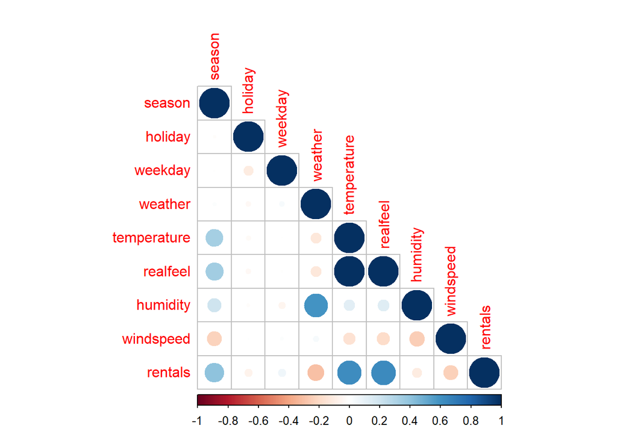

```r
bikesNum <- bikes %>%
  select(-date)
rawcor <- cor(x = bikesNum) # correlation nums

corrplot(rawcor,  type = 'lower') # good looking
```

# regression

lm is wierd in that data is not the first default argument

```r
bikes_lm1 <- lm(data = bikes, rentals ~ temperature)
summary(bikes_lm1)
```

```
##
## Call:
## lm(formula = rentals ~ temperature, data = bikes)
##
## Residuals:
##     Min      1Q  Median      3Q     Max
## -4615.3 -1134.9  -104.4  1044.3  3737.8
##
## Coefficients:
##             Estimate Std. Error t value Pr(>|t|)
## (Intercept) -166.877    221.816  -0.752    0.452
## temperature   78.495      3.607  21.759   <2e-16 ***
## ---
## Signif. codes:  0 '***' 0.001 '**' 0.01 '*' 0.05 '.' 0.1 ' ' 1
##
## Residual standard error: 1509 on 729 degrees of freedom
## Multiple R-squared:  0.3937, Adjusted R-squared:  0.3929
## F-statistic: 473.5 on 1 and 729 DF,  p-value: < 2.2e-16
```

model interpretation

this is what the model is

###### Call: lm(formula = rentals ~temperature, data = bikes)

this is the descriptive stats for the residuals of the model min means our model over predicted the number of bikes by 4615 at least once. the max means that our model under predicted the number of bikes by 3737 at least once. when median is (-) then our model over predicts rentals on more than half the observations.

key: observed minus predicted

###### Residuals:

###### Min 1Q Median 3Q Max

###### -4615.3 -1134.9 -104.4 1044.3 3737.8

Estimate is the betas ()for each predictor. Std = spread from the estimate, lower is better. t = effective size of predictor p = significance of predictor

###### Coefficients:

###### Estimate Std. Error t value Pr(>|t|)

###### (Intercept) -166.877 221.816 -0.752 0.452

###### temperature 78.495 3.607 21.759 <2e-16 ***

###### Signif. codes: 0 ‘**’ 0.001 ’**’ 0.01 ’’ 0.05 ‘.’ 0.1 ’ ’ 1

RSE = measures $lack$ $of$ $fit$ this means on average the model predicted 1509 bikes away from the true values. ( in units of Y)

multiple R^2 (a.k.a coeficcient of determination) = is a proportion, how much of the variability of the data is explained by the model. .39 = 39% of the variability in the data set is explained by the model.

adjusted R^2 = is adjusted for how many predictors are used. can be used to compare across models with differing number of predictors.

F-stat = tells if there is is a relationship between the predictors and the response variables. this one is large so we can say there is a strong relationship between the predictors and response vars. GIVEN that the p value is small.

p value = the likely hood that a relationship is due to chance. smaller is better.

###### Residual standard error: 1509 on 729 degrees of freedom

###### MultipleR-squared: 0.3937, AdjustedR-squared: 0.3929

###### F-statistic: 473.5 on 1 and 729 DF, p-value: < 2.2e-16

```r
bikes_lm2 <- lm(rentals~ humidity + windspeed + temperature, data = bikes)
summary(bikes_lm2)
```

```
##
## Call:
## lm(formula = rentals ~ humidity + windspeed + temperature, data = bikes)
##
## Residuals:
##     Min      1Q  Median      3Q     Max
## -4780.5 -1082.6   -62.2  1056.5  3653.5
##
## Coefficients:
##              Estimate Std. Error t value Pr(>|t|)
## (Intercept)  2706.002    367.483   7.364 4.86e-13 ***
## humidity    -3100.123    383.992  -8.073 2.83e-15 ***
## windspeed    -115.463     17.028  -6.781 2.48e-11 ***
## temperature    78.316      3.464  22.606  < 2e-16 ***
## ---
## Signif. codes:  0 '***' 0.001 '**' 0.01 '*' 0.05 '.' 0.1 ' ' 1
##
## Residual standard error: 1425 on 727 degrees of freedom
## Multiple R-squared:  0.4609, Adjusted R-squared:  0.4587
## F-statistic: 207.2 on 3 and 727 DF,  p-value: < 2.2e-16
```

# Diagnostics

these are assumption checks that have to do with the residuals

- residuals have a mean of zero
- residuals are normally distributed
- residuals have equal variance across the values of the independent variable (homoscedasticity)
- residuals are not correlated

# packages

```r
library(olsrr)
library(lmtest) # has bptest
library(car) # has durbin watson test
```

```r
# Zero mean of residuals?
mean(bikes_lm2$residuals)
```

```
## [1] -2.962843e-13
```

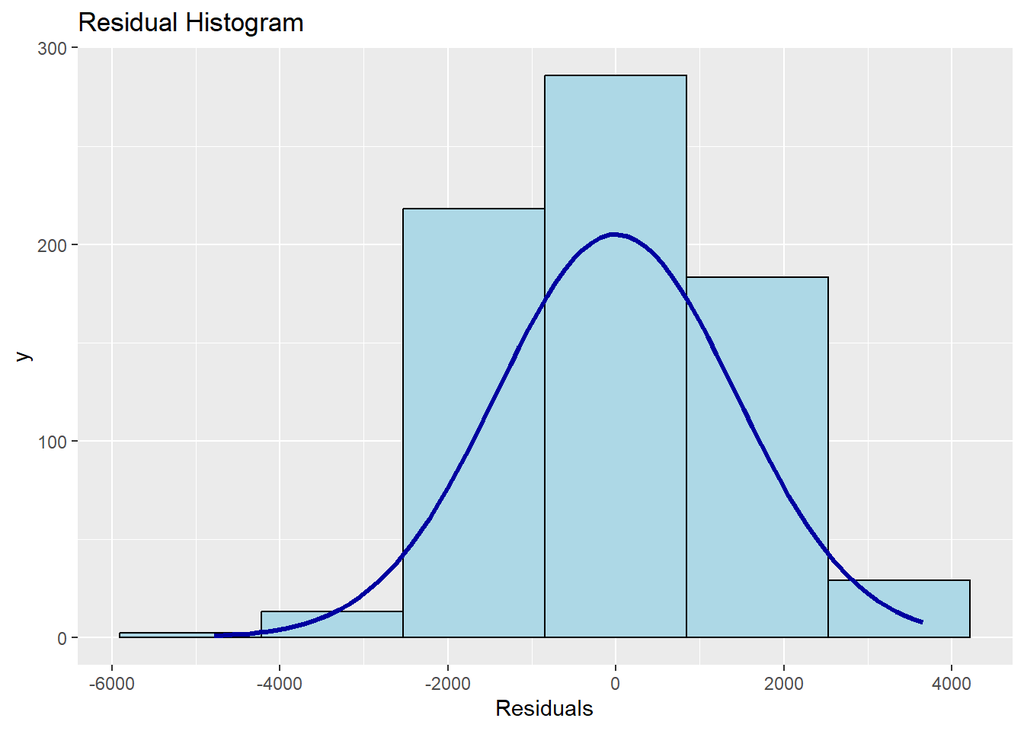

```r
# normally distributed?
ols_plot_resid_hist(bikes_lm2)
```

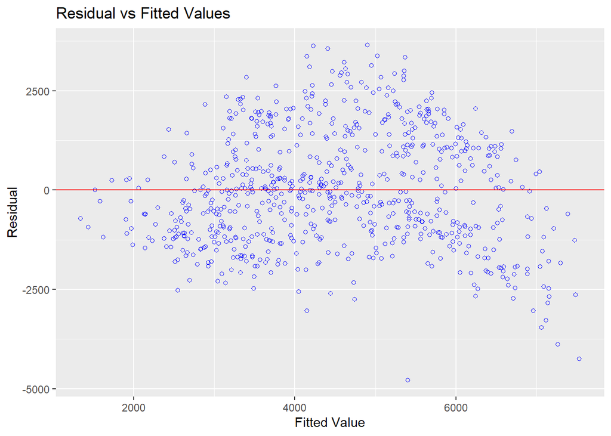

```r
ols_plot_resid_fit(bikes_lm2)
```

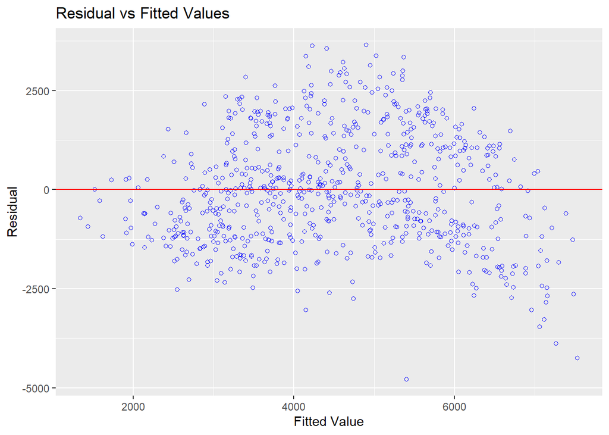

```r
# homoscedasticity
# there are two ways to test for this. can use the Breusch-Pagan stats test. or can plot it. we gonna plot it. is the otherside of heteroscedasticity. we dont want heteroscedasticity (this is a bias in the distribution of resuduals). but rather we want there to be no pattern in how to residuals are distributed around the model fit (the line).

ols_plot_resid_fit(bikes_lm2)
```

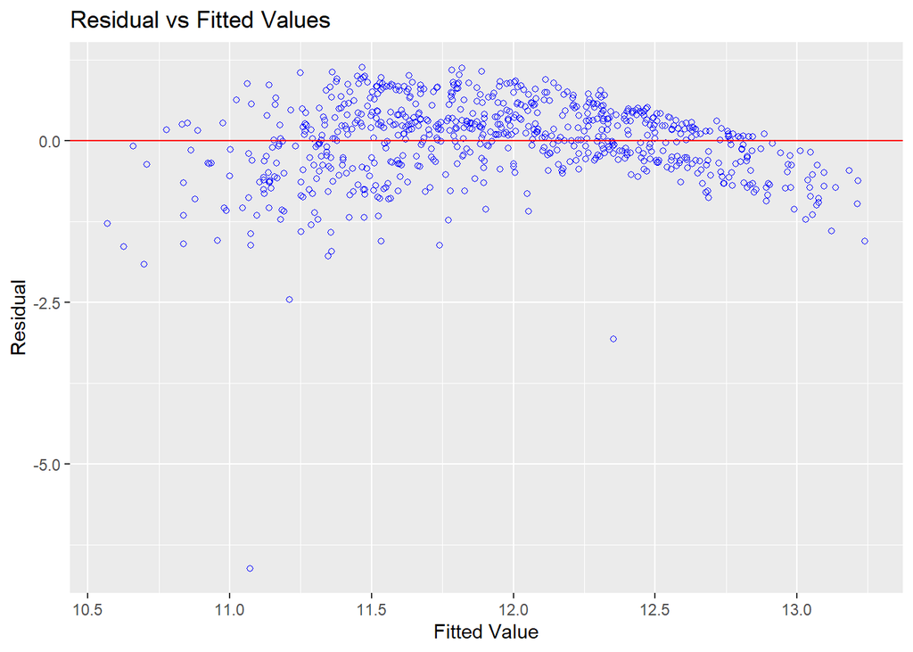

```r
# looks like our data is a bit heterscedastic (this is the bad one). we can fix this using weighted regression. or we can do a log transformation on the dependant variable.

ols_plot_resid_fit(lm(log2(rentals)~ temperature + humidity + windspeed, data = bikes))
```

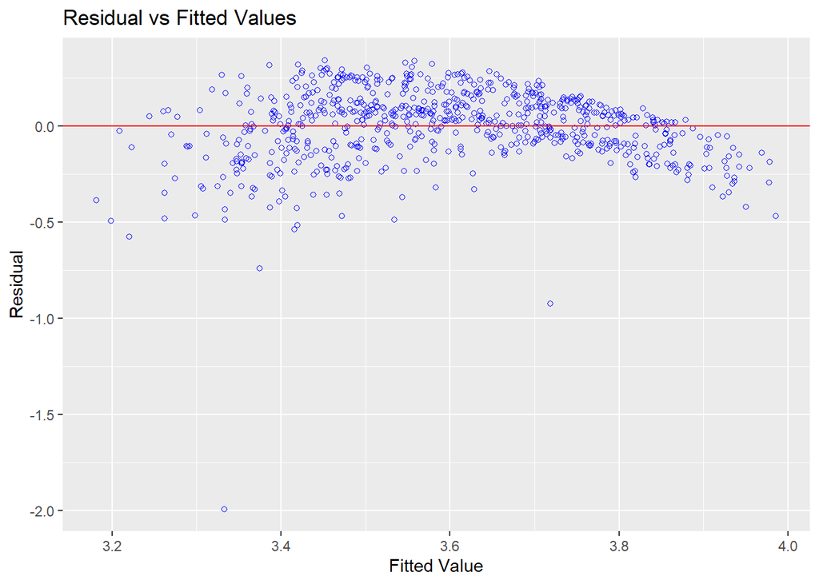

```r
ols_plot_resid_fit(lm(log10(rentals)~ temperature + humidity + windspeed, data = bikes))
```

```r
# this doesnt seem to have helped, but we could run the stats test to actually see if there is a difference.


bptest(lm(log2(rentals)~ temperature + humidity + windspeed, data = bikes))
```

```
##
##  studentized Breusch-Pagan test
##
## data:  lm(log2(rentals) ~ temperature + humidity + windspeed, data = bikes)
## BP = 15.273, df = 3, p-value = 0.001597
```

```r
# it looks like we reduced heterscedasticity by half. this is pretty good I think. the problem is that now our output is hard to interpret bc its in log2 instead fo the oreginal values.

# Residual Autocorrelation

# the test is call Durbin-Watson test. DW goes from 0 to 4.  with 0-2 being positive autocorrelation and 2-4 being negative autocorrelation. 2 = no autocorrelation, which is what we want.


durbinWatsonTest(bikes_lm2)
```

[output not shown]

[output not shown]

```
##  lag Autocorrelation D-W Statistic p-value
##    1       0.7963326     0.4042771       0
##  Alternative hypothesis: rho != 0
```

```r
#DW stat is .404

# this shows us that our residuals are positively auto correlated. this can be fixed by adding new predictors to the model or transform some of the predictors.

durbinWatsonTest(lm(log2(rentals) ~ humidity + windspeed + temperature, data = bikes))
```

```
##  lag Autocorrelation D-W Statistic p-value
##    1        0.622834     0.7474104       0
##  Alternative hypothesis: rho != 0
```

```r
# DW stat = .747

# the log transformation has made the residuals less positively correlated, which is good.
```

# Influencial Point Analysis

this is the advanced version of looking for outliers. in simple linear regression, we could just make a box plot to find outliers but with multiple predictors a combination of normal seeming data points could aggregate into an observation that is extreme when compared to the rest of the data set.

to test for this use cooks distance.

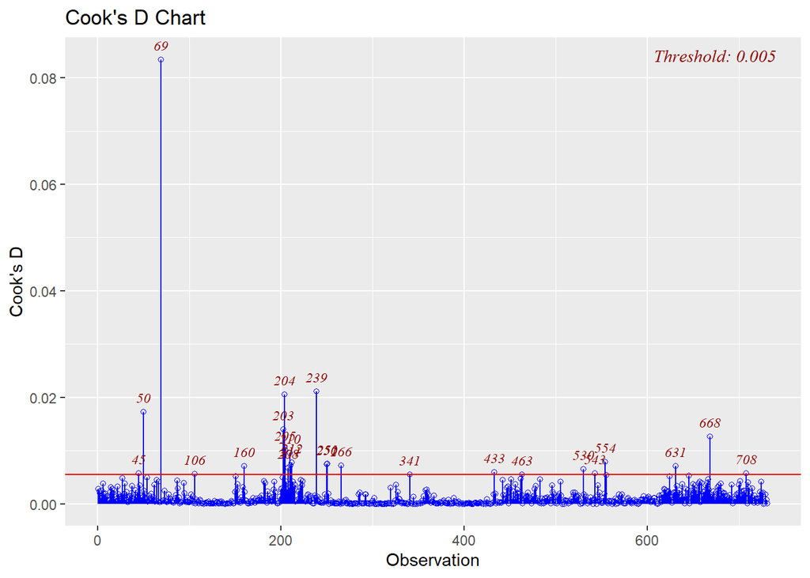

```r
ols_plot_cooksd_chart(bikes_lm2)
```

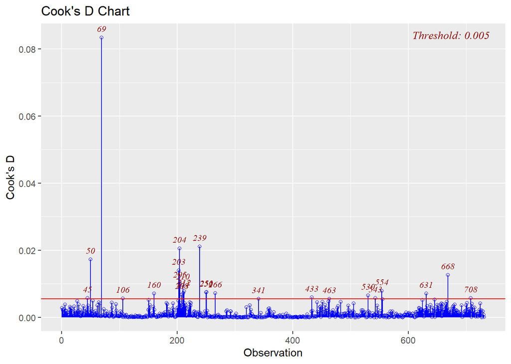

```r
# to extract these outliers, bc there are a number of them ( use ols_plot_cooksd_bar to highlight outliers)

cooks_outliers <- ols_plot_cooksd_chart(bikes_lm2)
```

```r
# these are all the most influencial points.
arrange(subset(x = cooks_outliers$data, subset = color == 'outlier'), decreasing = desc(cd))
```

```
##     obs          cd   color fct_color txt
## 69   69 0.083466470 outlier   outlier  69
## 239 239 0.021074076 outlier   outlier 239
## 204 204 0.020516659 outlier   outlier 204
## 50   50 0.017264207 outlier   outlier  50
## 203 203 0.013923865 outlier   outlier 203
## 668 668 0.012660294 outlier   outlier 668
## 205 205 0.010164468 outlier   outlier 205
## 210 210 0.009595062 outlier   outlier 210
## 554 554 0.007894590 outlier   outlier 554
## 212 212 0.007714449 outlier   outlier 212
## 251 251 0.007507810 outlier   outlier 251
## 250 250 0.007365982 outlier   outlier 250
## 266 266 0.007179789 outlier   outlier 266
## 211 211 0.007177980 outlier   outlier 211
## 160 160 0.007120294 outlier   outlier 160
## 631 631 0.007088713 outlier   outlier 631
## 208 208 0.006705139 outlier   outlier 208
## 530 530 0.006504121 outlier   outlier 530
## 433 433 0.005979306 outlier   outlier 433
## 543 543 0.005768543 outlier   outlier 543
## 45   45 0.005713411 outlier   outlier  45
## 708 708 0.005688624 outlier   outlier 708
## 106 106 0.005603058 outlier   outlier 106
## 341 341 0.005517340 outlier   outlier 341
## 463 463 0.005486960 outlier   outlier 463
```

```r
# compare summaries


bikes[69,c('rentals', 'humidity', 'windspeed', 'temperature')]
```

```
## # A tibble: 1 × 4
##   rentals humidity windspeed temperature
##     <dbl>    <dbl>     <dbl>       <dbl>
## 1     623        0      10.9        50.5
```

```r
outlier_index <- subset(x = cooks_outliers$data, subset = color == 'outlier')

summary(bikes[outlier_index$obs,c('rentals', 'humidity', 'windspeed', 'temperature')])
```

```
##     rentals        humidity        windspeed       temperature
##  Min.   :  22   Min.   :0.0000   Min.   : 3.263   Min.   :49.89
##  1st Qu.:1842   1st Qu.:0.4658   1st Qu.: 6.809   1st Qu.:54.61
##  Median :3606   Median :0.5675   Median : 8.024   Median :71.23
##  Mean   :3617   Mean   :0.5960   Mean   :10.202   Mean   :70.76
##  3rd Qu.:4840   3rd Qu.:0.8800   3rd Qu.:14.291   3rd Qu.:85.77
##  Max.   :8395   Max.   :0.9725   Max.   :21.127   Max.   :90.50
```

```r
summary(bikes[-outlier_index$obs ,c('rentals', 'humidity', 'windspeed', 'temperature')])
```

```
##     rentals        humidity        windspeed        temperature
##  Min.   : 431   Min.   :0.2758   Min.   : 0.9322   Min.   :22.60
##  1st Qu.:3206   1st Qu.:0.5235   1st Qu.: 5.5992   1st Qu.:45.62
##  Median :4570   Median :0.6308   Median : 7.5082   Median :59.30
##  Mean   :4536   Mean   :0.6290   Mean   : 7.8498   Mean   :59.11
##  3rd Qu.:5990   3rd Qu.:0.7296   3rd Qu.: 9.6318   3rd Qu.:72.87
##  Max.   :8714   Max.   :0.9625   Max.   :17.5801   Max.   :88.17
```

```r
# the averages are totally different so we get rid of those observations

bikes2 <- bikes[-outlier_index$obs,]
```

# Multicollinearity

when variables are highly correlated. can inflate sd, which is bad. hard to tell which predictors are doing the work. test for variance inflation factor $VIF$.  
if $VIF$ is greater than 5  
or tolerance is less than .2,  
you need to make a correction.

```r
ols_vif_tol(bikes_lm2)
```

```
##     Variables Tolerance      VIF
## 1    humidity 0.9303623 1.074850
## 2   windspeed 0.9220157 1.084580
## 3 temperature 0.9668533 1.034283
```

```r
# it looks fine
```

how to fix it if there is an issue… 1. drop theproblematic variables form the analysis 2. combine the collinear predictors into one variable( idk how tho)

# improving the model

### non - linear relationships

we are assuming the relationship between all our predictors and our response is linear. to accomodate for a non- linear relationship we can transform our predictors. this is called a polynomial regression. since the relationships look quadratic, we can ^2 each variable. and add it to the model

```r
bikes2 <- bikes2 %>%
  mutate(humidity2 = humidity^2,
         windspeed2 = windspeed^2,
         temperature2 = temperature^2)

# did it work

bikes2 %>%
  select(humidity, humidity2) %>%
  head()
```

```
## # A tibble: 6 × 2
##   humidity humidity2
##      <dbl>     <dbl>
## 1    0.806     0.649
## 2    0.696     0.485
## 3    0.437     0.191
## 4    0.590     0.349
## 5    0.437     0.191
## 6    0.518     0.269
```

```r
bikes_lm3 <- lm(rentals ~ humidity +
                  windspeed +
                  temperature+
                  humidity2 +
                  windspeed2 +
                  temperature2,
                data = bikes2)

summary(bikes_lm3)
```

```
##
## Call:
## lm(formula = rentals ~ humidity + windspeed + temperature + humidity2 +
##     windspeed2 + temperature2, data = bikes2)
##
## Residuals:
##      Min       1Q   Median       3Q      Max
## -3153.77  -950.91   -97.23  1034.22  3000.12
##
## Coefficients:
##                Estimate Std. Error t value Pr(>|t|)
## (Intercept)  -8335.7021  1128.0572  -7.389 4.22e-13 ***
## humidity      6203.5583  2727.8537   2.274 0.023259 *
## windspeed     -147.3909    63.5284  -2.320 0.020624 *
## temperature    397.0970    25.7213  15.438  < 2e-16 ***
## humidity2    -8324.7772  2128.2637  -3.912 0.000101 ***
## windspeed2       1.5802     3.5370   0.447 0.655191
## temperature2    -2.6839     0.2175 -12.339  < 2e-16 ***
## ---
## Signif. codes:  0 '***' 0.001 '**' 0.01 '*' 0.05 '.' 0.1 ' ' 1
##
## Residual standard error: 1213 on 699 degrees of freedom
## Multiple R-squared:  0.6022, Adjusted R-squared:  0.5988
## F-statistic: 176.4 on 6 and 699 DF,  p-value: < 2.2e-16
```

```r
# we are up to 60% YAYAYA, bikes wind2 doesnt do anything sooo....

bikes_lm3 <- lm(rentals ~ humidity +
                  windspeed +
                  temperature+
                  humidity2 +
                  # windspeed2 +
                  temperature2,
                data = bikes2)
summary(bikes_lm3)
```

```
##
## Call:
## lm(formula = rentals ~ humidity + windspeed + temperature + humidity2 +
##     temperature2, data = bikes2)
##
## Residuals:
##     Min      1Q  Median      3Q     Max
## -3167.5  -945.0  -106.7  1034.4  2984.6
##
## Coefficients:
##                Estimate Std. Error t value Pr(>|t|)
## (Intercept)  -8441.8304  1102.1300  -7.660 6.22e-14 ***
## humidity      6172.7633  2725.4232   2.265 0.023825 *
## windspeed     -119.8659    15.4807  -7.743 3.41e-14 ***
## temperature    397.6880    25.6726  15.491  < 2e-16 ***
## humidity2    -8298.1097  2126.2098  -3.903 0.000104 ***
## temperature2    -2.6903     0.2169 -12.402  < 2e-16 ***
## ---
## Signif. codes:  0 '***' 0.001 '**' 0.01 '*' 0.05 '.' 0.1 ' ' 1
##
## Residual standard error: 1213 on 700 degrees of freedom
## Multiple R-squared:  0.6021, Adjusted R-squared:  0.5993
## F-statistic: 211.8 on 5 and 700 DF,  p-value: < 2.2e-16
```

# categorical Predictors

```r
#fisrt make sure they are factors
str(bikes2)
```

```
## tibble [706 × 13] (S3: tbl_df/tbl/data.frame)
##  $ date        : Date[1:706], format: "2011-01-01" "2011-01-02" ...
##  $ season      : num [1:706] 1 1 1 1 1 1 1 1 1 1 ...
##  $ holiday     : num [1:706] 0 0 0 0 0 0 0 0 0 0 ...
##  $ weekday     : num [1:706] 6 0 1 2 3 4 5 6 0 1 ...
##  $ weather     : num [1:706] 2 2 1 1 1 1 2 2 1 1 ...
##  $ temperature : num [1:706] 46.7 48.4 34.2 34.5 36.8 ...
##  $ realfeel    : num [1:706] 46.4 45.2 25.7 28.4 30.4 ...
##  $ humidity    : num [1:706] 0.806 0.696 0.437 0.59 0.437 ...
##  $ windspeed   : num [1:706] 6.68 10.35 10.34 6.67 7.78 ...
##  $ rentals     : num [1:706] 985 801 1349 1562 1600 ...
##  $ humidity2   : num [1:706] 0.649 0.485 0.191 0.349 0.191 ...
##  $ windspeed2  : num [1:706] 44.6 107.1 106.9 44.5 60.5 ...
##  $ temperature2: num [1:706] 2182 2338 1170 1192 1354 ...
```

```r
# if they arent, make them be
names <- names(bikes2[, c(2:5)])

bikes2[,names]<- (lapply(X = bikes2[,names], factor))

#check it
str(bikes2)
```

```
## tibble [706 × 13] (S3: tbl_df/tbl/data.frame)
##  $ date        : Date[1:706], format: "2011-01-01" "2011-01-02" ...
##  $ season      : Factor w/ 4 levels "1","2","3","4": 1 1 1 1 1 1 1 1 1 1 ...
##  $ holiday     : Factor w/ 2 levels "0","1": 1 1 1 1 1 1 1 1 1 1 ...
##  $ weekday     : Factor w/ 7 levels "0","1","2","3",..: 7 1 2 3 4 5 6 7 1 2 ...
##  $ weather     : Factor w/ 3 levels "1","2","3": 2 2 1 1 1 1 2 2 1 1 ...
##  $ temperature : num [1:706] 46.7 48.4 34.2 34.5 36.8 ...
##  $ realfeel    : num [1:706] 46.4 45.2 25.7 28.4 30.4 ...
##  $ humidity    : num [1:706] 0.806 0.696 0.437 0.59 0.437 ...
##  $ windspeed   : num [1:706] 6.68 10.35 10.34 6.67 7.78 ...
##  $ rentals     : num [1:706] 985 801 1349 1562 1600 ...
##  $ humidity2   : num [1:706] 0.649 0.485 0.191 0.349 0.191 ...
##  $ windspeed2  : num [1:706] 44.6 107.1 106.9 44.5 60.5 ...
##  $ temperature2: num [1:706] 2182 2338 1170 1192 1354 ...
```

```r
# good job Jason!!!!!


bikes2 %>%
  select(season, holiday, weekday, weather) %>%
  summary()
```

```
##  season  holiday weekday weather
##  1:177   0:685   0:103   1:448
##  2:180   1: 21   1:103   2:243
##  3:175           2:103   3: 15
##  4:174           3:100
##                  4:100
##                  5:101
##                  6: 96
```

```r
# naming factor values, he uses recode, but should use fct_recode instead.
bikes2 <- bikes2 %>%
  mutate(season = fct_recode(season,
                             Winter = '1',
                             Spring = '2',
                             Summer = '3',
                             Fall =   '4'),
         holiday = fct_recode(holiday,
                              No =  '0',
                              Yes = '1'),
         weekday = fct_recode(weekday,
                              Sunday =    "0",
                              Monday =    "1",
                              Tuesday =   "2",
                              Wednesday = "3",
                              Thursday =  "4",
                              Friday =    "5",
                              Saturday =  "6"),
         weather = fct_recode(weather,
                              'Light Precipitation' =  '2',
                              Clear =                 '1',
                              'Heavy Precipitation' = '3'))
# got to have the summary outsiude of the pipe, otherwise bikes2 becomes the table of results. which makes perfet sense.
ji('happy')
```

```
## 😀
```

```r
summary(bikes2)
```

```
##       date               season    holiday        weekday
##  Min.   :2011-01-01   Winter:177   No :685   Sunday   :103
##  1st Qu.:2011-07-01   Spring:180   Yes: 21   Monday   :103
##  Median :2012-01-05   Summer:175             Tuesday  :103
##  Mean   :2012-01-02   Fall  :174             Wednesday:100
##  3rd Qu.:2012-07-03                          Thursday :100
##  Max.   :2012-12-31                          Friday   :101
##                                              Saturday : 96
##                 weather     temperature       realfeel         humidity
##  Clear              :448   Min.   :22.60   Min.   : 12.59   Min.   :0.2758
##  Light Precipitation:243   1st Qu.:45.62   1st Qu.: 42.46   1st Qu.:0.5235
##  Heavy Precipitation: 15   Median :59.30   Median : 60.16   Median :0.6308
##                            Mean   :59.11   Mean   : 59.06   Mean   :0.6290
##                            3rd Qu.:72.87   3rd Qu.: 75.26   3rd Qu.:0.7296
##                            Max.   :88.17   Max.   :101.37   Max.   :0.9625
##
##    windspeed          rentals       humidity2         windspeed2
##  Min.   : 0.9322   Min.   : 431   Min.   :0.07608   Min.   :  0.869
##  1st Qu.: 5.5992   1st Qu.:3206   1st Qu.:0.27410   1st Qu.: 31.352
##  Median : 7.5082   Median :4570   Median :0.39795   Median : 56.374
##  Mean   : 7.8498   Mean   :4536   Mean   :0.41425   Mean   : 71.358
##  3rd Qu.: 9.6318   3rd Qu.:5990   3rd Qu.:0.53229   3rd Qu.: 92.772
##  Max.   :17.5801   Max.   :8714   Max.   :0.92641   Max.   :309.060
##
##   temperature2
##  Min.   : 510.9
##  1st Qu.:2081.5
##  Median :3516.6
##  Mean   :3729.9
##  3rd Qu.:5310.3
##  Max.   :7774.0
##
```

# on interpreting categorical coefficients.

the estimate is the defference between that factor and the baseline factor ( the baseline factor does not have an estimate). the estimate is the differnce between the factor and the baseline (ex. difference in bike rentals between spring and winter)

```r
bikes_lm4 <- lm(rentals ~ humidity +
                  windspeed +
                  temperature +
                  humidity2 +
                  temperature2 +
                  season,
                data = bikes2)
summary(bikes_lm4)
```

```
##
## Call:
## lm(formula = rentals ~ humidity + windspeed + temperature + humidity2 +
##     temperature2 + season, data = bikes2)
##
## Residuals:
##     Min      1Q  Median      3Q     Max
## -3623.7  -960.4   -39.9   987.0  3363.4
##
## Coefficients:
##                Estimate Std. Error t value Pr(>|t|)
## (Intercept)  -6737.0068  1118.5289  -6.023 2.77e-09 ***
## humidity      5210.4033  2667.1441   1.954 0.051154 .
## windspeed     -103.7065    15.2032  -6.821 1.96e-11 ***
## temperature    331.2778    29.0463  11.405  < 2e-16 ***
## humidity2    -7626.8064  2077.8323  -3.671 0.000261 ***
## temperature2    -2.1790     0.2503  -8.706  < 2e-16 ***
## seasonSpring   489.6013   168.9875   2.897 0.003882 **
## seasonSummer   581.3724   221.2979   2.627 0.008801 **
## seasonFall     994.2943   145.9958   6.810 2.10e-11 ***
## ---
## Signif. codes:  0 '***' 0.001 '**' 0.01 '*' 0.05 '.' 0.1 ' ' 1
##
## Residual standard error: 1175 on 697 degrees of freedom
## Multiple R-squared:  0.6282, Adjusted R-squared:  0.624
## F-statistic: 147.2 on 8 and 697 DF,  p-value: < 2.2e-16
```

# adding interaction effects

```r
bikes_lm5 <- lm(rentals ~ humidity +
                  windspeed +
                  temperature +
                  humidity2 +
                  temperature2 +
                  season +
                  windspeed * weather,
                data = bikes2)
summary(bikes_lm5)
```

```
##
## Call:
## lm(formula = rentals ~ humidity + windspeed + temperature + humidity2 +
##     temperature2 + season + windspeed * weather, data = bikes2)
##
## Residuals:
##     Min      1Q  Median      3Q     Max
## -3620.9  -961.8   -56.5   980.1  3224.9
##
## Coefficients:
##                                        Estimate Std. Error t value Pr(>|t|)
## (Intercept)                          -7032.1566  1178.2062  -5.969 3.82e-09 ***
## humidity                              5011.7326  2843.8582   1.762 0.078459 .
## windspeed                              -68.2215    19.7901  -3.447 0.000601 ***
## temperature                            329.9987    28.9740  11.389  < 2e-16 ***
## humidity2                            -7073.1818  2249.3058  -3.145 0.001734 **
## temperature2                            -2.1794     0.2494  -8.739  < 2e-16 ***
## seasonSpring                           519.6417   169.0658   3.074 0.002198 **
## seasonSummer                           635.4740   221.8383   2.865 0.004302 **
## seasonFall                            1045.5251   146.1096   7.156 2.12e-12 ***
## weatherLight Precipitation             566.2684   263.2216   2.151 0.031798 *
## weatherHeavy Precipitation           -1276.6609   990.5272  -1.289 0.197873
## windspeed:weatherLight Precipitation   -83.0116    31.1330  -2.666 0.007847 **
## windspeed:weatherHeavy Precipitation    46.4121    92.0607   0.504 0.614318
## ---
## Signif. codes:  0 '***' 0.001 '**' 0.01 '*' 0.05 '.' 0.1 ' ' 1
##
## Residual standard error: 1168 on 693 degrees of freedom
## Multiple R-squared:  0.6346, Adjusted R-squared:  0.6283
## F-statistic: 100.3 on 12 and 693 DF,  p-value: < 2.2e-16
```

# Choosing variables

1. forward selection try every combo for var 1, then try all of them for var 2 etc… asses using Residual sum of square (RSS). find the highest RSS, then move to add the next var. cant use this if there are more var then obs.
2. backward elimination include all the vars, the get rid of the ones with the least predictive value.
3. mixed selection

```r
# using lubraidate

bikes2 <- bikes2 %>%
  mutate(day = as.numeric(date-min(date)), # days since program began
         month = as.factor(month(date)),   # months
         year = as.factor(year(date))) %>%
  select( - date) # get rid of date var
```

```r
ols_step_both_p( model = lm(
                            rentals ~ # if you log() this the output keeps some more vars but is hard to interpret and also does actually perform all that much better.
                              humidity +
                              weekday +
                              holiday +
                              temperature +
                              humidity2 +
                              temperature2 +
                              season +
                              windspeed * weather +
                              realfeel +
                              day +
                              month +
                              year,
                            data = bikes2),
                pent = .2, # p enter, the p value required to include it in the model
                prem = .01, # p remove, the p value to remove a var from model
                progress = F, # we dont want to see all this junk
                details = T # this has like insane amounts of out put if T,. ig we need it for the last bit
)
```

```
## Stepwise Selection Method
## ---------------------------
##
## Candidate Terms:
##
## 1. humidity
## 2. weekday
## 3. holiday
## 4. temperature
## 5. humidity2
## 6. temperature2
## 7. season
## 8. windspeed
## 9. weather
## 10. realfeel
## 11. day
## 12. month
## 13. year
## 14. windspeed:weather
##
## We are selecting variables based on p value...
##
##
## Stepwise Selection: Step 1
##
## - realfeel added
##
##                            Model Summary
## -------------------------------------------------------------------
## R                       0.666       RMSE                  1429.957
## R-Squared               0.444       Coef. Var               31.526
## Adj. R-Squared          0.443       MSE                2044777.960
## Pred R-Squared          0.441       MAE                   1183.067
## -------------------------------------------------------------------
##  RMSE: Root Mean Square Error
##  MSE: Mean Square Error
##  MAE: Mean Absolute Error
##
##                                      ANOVA
## -------------------------------------------------------------------------------
```

[output cut: 1668 more lines]

```
##                        weekdayFriday      437.525        95.295        0.080     4.591    0.000      250.414      624.635
##                      weekdaySaturday      464.040        95.748        0.083     4.846    0.000      276.040      652.040
##                         seasonSpring      851.685       159.441        0.194     5.342    0.000      538.626     1164.743
##                         seasonSummer      980.975       192.287        0.221     5.102    0.000      603.424     1358.526
##                           seasonFall     1624.307       160.785        0.366    10.102    0.000     1308.608     1940.006
##                           holidayYes     -553.809       157.964       -0.049    -3.506    0.000     -863.968     -243.649
##                         temperature2       -1.641         0.172       -1.555    -9.522    0.000       -1.979       -1.302
##                          temperature      241.043        19.717        1.934    12.225    0.000      202.329      279.757
##                             year2012     1897.337        52.237        0.496    36.322    0.000     1794.771     1999.904
##                            windspeed      -53.781        10.012       -0.088    -5.371    0.000      -73.440      -34.122
##                             humidity     6088.026      1597.069        0.433     3.812    0.000     2952.215     9223.838
##                            humidity2    -6543.385      1252.304       -0.593    -5.225    0.000    -9002.257    -4084.513
## windspeed:weatherLight Precipitation      -47.327         8.255       -0.102    -5.733    0.000      -63.536      -31.119
## windspeed:weatherHeavy Precipitation     -106.682        20.075       -0.085    -5.314    0.000     -146.100      -67.265
## --------------------------------------------------------------------------------------------------------------------------
```

```
##
##                                      Stepwise Selection Summary
## -----------------------------------------------------------------------------------------------------
##                               Added/                   Adj.
## Step        Variable         Removed     R-Square    R-Square      C(p)          AIC          RMSE
## -----------------------------------------------------------------------------------------------------
##    1        realfeel         addition       0.444       0.443    2485.8090    12266.2830    1429.9573
##    2           day           addition       0.721       0.720     899.0440    11781.1939    1013.4814
##    3    windspeed:weather    addition       0.765       0.763     649.8410    11666.5370     932.4671
##    4          month          addition       0.820       0.815     337.6480    11501.1578     823.0760
##    5         weekday         addition       0.829       0.823     288.0660    11477.0170     805.7925
##    6         season          addition       0.850       0.844     168.9290    11390.0745     756.1230
##    7         holiday         addition       0.852       0.846     158.5180    11381.8230     751.2058
##    8      temperature2       addition       0.854       0.848     149.7690    11374.8218     746.9825
##    9       temperature       addition       0.865       0.860      85.7640    11318.8851     717.4822
##   10        realfeel         removal        0.865       0.860      83.7720    11316.8924     716.9566
##   11          year           addition       0.868       0.862      72.4330    11306.5835     711.2585
##   12           day           removal        0.867       0.862      73.6180    11307.5420     712.2245
##   13        windspeed        addition       0.867       0.862      75.6180    11307.5420     712.2245
##   14        humidity         addition       0.877       0.872      19.1520    11253.1529     684.8471
##   15        humidity2        addition       0.882       0.877      -6.1430    11227.2005     671.9194
##   16         weather         addition       0.882       0.877      -5.6590    11229.6159     672.1608
##   17         weather         removal        0.882       0.877      -6.1430    11227.2005     671.9194
## -----------------------------------------------------------------------------------------------------
```

# results

so in the end we were able to build a model that could predict 87% of the variability in our dataset. unfortunately we did not use a test train set so we cant test our model to see if we over fit it. my guess is that we did, to some degree. but thats like whateves bc this is just for funzies 😄